00327_example_8.1_of_section_8.2.1.R

```r
# example 8.1 of section 8.2.1
# (example 8.1 of section 8.2.1)  : Advanced Data Preparation : KDD and KDD Cup 2009 : Getting started with KDD Cup 2009 data
# Title: Preparing the KDD data for analysis

d <- read.table('../KDD2009/orange_small_train.data.gz',    # Note: 1
   header = TRUE,
   sep = '\t',
   na.strings = c('NA', ''))    # Note: 2

churn <- read.table('../KDD2009/orange_small_train_churn.labels.txt',
   header = FALSE, sep = '\t')  # Note: 3
d$churn <- churn$V1     # Note: 4

set.seed(729375)    # Note: 5
rgroup <- base::sample(c('train', 'calibrate', 'test'),     # Note: 6
   nrow(d),
   prob = c(0.8, 0.1, 0.1),
   replace = TRUE)
dTrain <- d[rgroup=='train', , drop = FALSE]
dCal <- d[rgroup=='calibrate', , drop = FALSE]
dTrainAll <- d[rgroup %in% c('train', 'calibrate'), , drop = FALSE]
dTest <- d[rgroup == 'test', , drop = FALSE]

outcome <- 'churn'
vars <- setdiff(colnames(dTrainAll), outcome)

rm(list=c('d', 'churn', 'rgroup'))  # Note: 7

# Note 1:
#   Read the file of independent variables. All
#   data from
#   https://github.com/WinVector/PDSwR2/tree/master/KDD2009.

# Note 2:
#   Treat both NA and the empty string as missing
#   data.

# Note 3:
#   Read known churn outcomes.

# Note 4:
#   Add churn as a new column.

# Note 5:
#   By setting the seed to the pseudo-random
#   number generator, we make our work reproducible:
#   someone redoing it will see the exact same
#   results.

# Note 6:
#   Split data into train, calibration, and test sets.
#   Explicitly specify the base::sample() function to avoid
#   name collision with dplyr::sample(), if the dplyr package is loaded.

# Note 7:
#   Remove unneeded objects from workspace.
```

00328_informalexample_8.1_of_section_8.2.1.R

```r
# informalexample 8.1 of section 8.2.1
# (informalexample 8.1 of section 8.2.1)  : Advanced Data Preparation : KDD and KDD Cup 2009 : Getting started with KDD Cup 2009 data

outcome_summary <- table(
   churn = dTrain[, outcome],   # Note: 1
   useNA = 'ifany')     # Note: 2

knitr::kable(outcome_summary)
```

| churn | Freq |
| --- | --- |
| -1 | 37110 |
| 1 | 2943 |

```r
# Note 1:
#   Tabulate levels of churn outcome.

# Note 2:
#   Include NA values in tabulation.
```

00329_informalexample_8.2_of_section_8.2.1.R

```r
# informalexample 8.2 of section 8.2.1
# (informalexample 8.2 of section 8.2.1)  : Advanced Data Preparation : KDD and KDD Cup 2009 : Getting started with KDD Cup 2009 data

outcome_summary["1"]/sum(outcome_summary)   # Note: 1
```

```
##          1
## 0.07347764
```

```r
#          1
# 0.07347764

# Note 1:
#   Estimate observed churn rate or prevelance.
```

00330_example_8.2_of_section_8.2.2.R

```r
# example 8.2 of section 8.2.2
# (example 8.2 of section 8.2.2)  : Advanced Data Preparation : KDD and KDD Cup 2009 : The Bull in The China Shop Approach
# Title: Attempting to model without preparation

library("wrapr")    # Note: 1
outcome <- 'churn'
vars <- setdiff(colnames(dTrainAll), outcome)

formula1 <- mk_formula("churn", vars, outcome_target = 1)   # Note: 2
model1 <- glm(formula1, data = dTrainAll, family = binomial)    # Note: 3
```

```
## Error in `contrasts<-`(`*tmp*`, value = contr.funs[1 + isOF[nn]]): contrasts can be applied only to factors with 2 or more levels
```

```r
# Error in `contrasts ...   # Note: 4

# Note 1:
#   Attach the wrapr package for convenience functions, such as mk_formula().

# Note 2:
#   Build a model formula specification asking churn==1 be predicted as a function of our explanatory variables.

# Note 3:
#   Ask the glm() function to build a logistic regression model.

# Note 4:
#   The attempt failed with an error.
```

00331_example_8.3_of_section_8.2.2.R

```r
# example 8.3 of section 8.2.2
# (example 8.3 of section 8.2.2)  : Advanced Data Preparation : KDD and KDD Cup 2009 : The Bull in The China Shop Approach
# Title: Trying just one variable

model2 <- glm((churn == 1) ~ Var1, data = dTrainAll, family = binomial)
summary(model2)
```

```
##
## Call:
## glm(formula = (churn == 1) ~ Var1, family = binomial, data = dTrainAll)
##
## Deviance Residuals:
##     Min       1Q   Median       3Q      Max
## -0.3685  -0.3685  -0.3685  -0.3661   2.3762
##
## Coefficients:
##               Estimate Std. Error z value Pr(>|z|)
## (Intercept) -2.6556108  0.1684722 -15.763   <2e-16 ***
## Var1        -0.0008306  0.0045203  -0.184    0.854
## ---
## Signif. codes:  0 '***' 0.001 '**' 0.01 '*' 0.05 '.' 0.1 ' ' 1
##
## (Dispersion parameter for binomial family taken to be 1)
##
##     Null deviance: 303.31  on 629  degrees of freedom
## Residual deviance: 303.27  on 628  degrees of freedom
##   (44395 observations deleted due to missingness)
## AIC: 307.27
##
## Number of Fisher Scoring iterations: 5
```

```r
#
# Call:
# glm(formula = (churn == 1) ~ Var1, family = binomial, data = dTrainAll)
#
# Deviance Residuals:
#     Min       1Q   Median       3Q      Max
# -0.3997  -0.3694  -0.3691  -0.3691   2.3326
#
# Coefficients:
#               Estimate Std. Error z value Pr(>|z|)
# (Intercept) -2.6523837  0.1674387 -15.841   <2e-16 ***
# Var1         0.0002429  0.0035759   0.068    0.946
# ---
# Signif. codes:  0 '***' 0.001 '**' 0.01 '*' 0.05 '.' 0.1 ' ' 1
#
# (Dispersion parameter for binomial family taken to be 1)
#
#     Null deviance: 302.09  on 620  degrees of freedom
# Residual deviance: 302.08  on 619  degrees of freedom
#   (44407 observations deleted due to missingness)     # Note: 1
# AIC: 306.08
#
# Number of Fisher Scoring iterations: 5

dim(dTrainAll)
```

```
## [1] 45025   231
```

```r
# [1] 45028   234

# Note 1:
#   This means the modeling procedure threw out this much (almost all) of our training data.
```

00332_informalexample_8.3_of_section_8.2.2.R

```r
# informalexample 8.3 of section 8.2.2
# (informalexample 8.3 of section 8.2.2)  : Advanced Data Preparation : KDD and KDD Cup 2009 : The Bull in The China Shop Approach

head(dTrainAll$Var200)
```

```
## [1] <NA>    <NA>    vynJTq9 <NA>    0v21jmy <NA>
## 15415 Levels: _84etK_ _9bTOWp _A3VKFm _bq4Nkb _ct4nkXBMp ... zzQ9udm
```

```r
# [1] <NA>    <NA>    vynJTq9 <NA>    0v21jmy <NA>
# 15415 Levels: _84etK_ _9bTOWp _A3VKFm _bq4Nkb _ct4nkXBMp ... zzQ9udm

length(unique(dTrainAll$Var200))
```

```
## [1] 14418
```

```r
# [1] 14391
```

00333_example_8.4_of_section_8.3.R

```r
# example 8.4 of section 8.3
# (example 8.4 of section 8.3)  : Advanced Data Preparation : Basic data preparation for classification
# Title: Basic data preparation for classification

library("vtreat")   # Note: 1
(parallel_cluster <- parallel::makeCluster(parallel::detectCores()))    # Note: 2
```

```
## socket cluster with 4 nodes on host 'localhost'
```

```r
treatment_plan <- vtreat::designTreatmentsC(    # Note: 3
  dTrain,
  varlist = vars,
  outcomename = "churn",
  outcometarget = 1,
  verbose = FALSE,
  parallelCluster = parallel_cluster)

# Note 1:
#   Attach the vtreat package for functions such as designTreatmentsC().

# Note 2:
#   Start up a parallel cluster to speed up calculation. If you don't want a parallel cluster just set parallel_cluster to NULL.

# Note 3:
#   Use designTreatmentsC() to learn the treatment plan from the training data. For a dataset of the size and complexity of KDD2009, this can take a few minutes.
```

00334_example_8.5_of_section_8.3.R

```r
# example 8.5 of section 8.3
# (example 8.5 of section 8.3)  : Advanced Data Preparation : Basic data preparation for classification
# Title: Preparing data with vtreat

dTrain_treated <- prepare(treatment_plan,
                          dTrain,
                          parallelCluster = parallel_cluster)

head(colnames(dTrain))
```

```
## [1] "Var1" "Var2" "Var3" "Var4" "Var5" "Var6"
```

```r
## [1] "Var1" "Var2" "Var3" "Var4" "Var5" "Var6"
head(colnames(dTrain_treated))          # Note: 1
```

```
## [1] "Var1"       "Var1_isBAD" "Var2"       "Var2_isBAD" "Var3"
## [6] "Var3_isBAD"
```

```r
## [1] "Var1"       "Var1_isBAD" "Var2"       "Var2_isBAD" "Var3"
## [6] "Var3_isBAD"

# Note 1:
#   Compare the columns of the original dTrain data to its treated counterpart.
```

00335_informalexample_8.4_of_section_8.3.1.R

```r
# informalexample 8.4 of section 8.3.1
# (informalexample 8.4 of section 8.3.1)  : Advanced Data Preparation : Basic data preparation for classification : The variable score frame

score_frame <-  treatment_plan$scoreFrame
t(subset(score_frame, origName %in% c("Var126", "Var189")))
```

```
##                   225            226            341
## varName           "Var126"       "Var126_isBAD" "Var189"
## varMoves          "TRUE"         "TRUE"         "TRUE"
## rsq               "0.0030859179" "0.0136377093" "0.0118934515"
## sig               "7.876602e-16" "2.453679e-64" "2.427376e-56"
## needsSplit        "FALSE"        "FALSE"        "FALSE"
## extraModelDegrees "0"            "0"            "0"
## origName          "Var126"       "Var126"       "Var189"
## code              "clean"        "isBAD"        "clean"
##                   342
## varName           "Var189_isBAD"
## varMoves          "TRUE"
## rsq               "0.0001004614"
## sig               "1.460688e-01"
## needsSplit        "FALSE"
## extraModelDegrees "0"
## origName          "Var189"
## code              "isBAD"
```

```r
#                   225            226            341            342
# varName           "Var126"       "Var126_isBAD" "Var189"       "Var189_isBAD"     # Note: 1
# varMoves          "TRUE"         "TRUE"         "TRUE"         "TRUE"         # Note: 2
# rsq               "0.0030859179" "0.0136377093" "0.0118934515" "0.0001004614"     # Note: 3
# sig               "7.876602e-16" "2.453679e-64" "2.427376e-56" "1.460688e-01"     # Note: 4
# needsSplit        "FALSE"        "FALSE"        "FALSE"        "FALSE"        # Note: 5
# extraModelDegrees "0"            "0"            "0"            "0"            # Note: 6
# origName          "Var126"       "Var126"       "Var189"       "Var189"       # Note: 7
# code              "clean"        "isBAD"        "clean"        "isBAD"            # Note: 8

# Note 1:
#   The name of the derived variable or column.

# Note 2:
#   An indicator that this variable is not always the same value (not a constant, which would be useless for modeling).

# Note 3:
#   The r-squared or pseudo-r-squared of the variable, what fraction of the outcome variation this variable can explain on its own in a linear model.

# Note 4:
#   The significance of the estimated r-squared.

# Note 5:
#   An indicator that when TRUE is a warning to the user that the variable is
#   hiding extra degrees of freedom (a measure of model complexity) and needs to be evaluated using cross-validation techniques..

# Note 6:
#   How complex is the variable, for a categorical variable this is related to the number of levels.

# Note 7:
#   Name of the original column the variable was derived from.

# Note 8:
#   Name of the type of transformation used to build this variable.
```

00336_informalexample_8.5_of_section_8.3.1.R

```r
# informalexample 8.5 of section 8.3.1
# (informalexample 8.5 of section 8.3.1)  : Advanced Data Preparation : Basic data preparation for classification : The variable score frame

t(subset(score_frame, origName == "Var218"))
```

```
##                   389            390            488
## varName           "Var218_catP"  "Var218_catB"  "Var218_lev_x_cJvF"
## varMoves          "TRUE"         "TRUE"         "TRUE"
## rsq               "0.010868743"  "0.012237170"  "0.005295590"
## sig               "1.214124e-51" "6.445785e-58" "4.902238e-26"
## needsSplit        " TRUE"        " TRUE"        "FALSE"
## extraModelDegrees "2"            "2"            "0"
## origName          "Var218"       "Var218"       "Var218"
## code              "catP"         "catB"         "lev"
##                   489
## varName           "Var218_lev_x_UYBR"
## varMoves          "TRUE"
## rsq               "0.001970131"
## sig               "1.218959e-10"
## needsSplit        "FALSE"
## extraModelDegrees "0"
## origName          "Var218"
## code              "lev"
```

```r
#                   389            390            488                 489
# varName           "Var218_catP"  "Var218_catB"  "Var218_lev_x_cJvF" "Var218_lev_x_UYBR"
# varMoves          "TRUE"         "TRUE"         "TRUE"              "TRUE"
# rsq               "0.011014574"  "0.012245152"  "0.005295590"       "0.001970131"
# sig               "2.602574e-52" "5.924945e-58" "4.902238e-26"      "1.218959e-10"
# needsSplit        " TRUE"        " TRUE"        "FALSE"             "FALSE"
# extraModelDegrees "2"            "2"            "0"                 "0"
# origName          "Var218"       "Var218"       "Var218"            "Var218"
# code              "catP"         "catB"         "lev"               "lev"
```

00337_informalexample_8.6_of_section_8.3.1.R

```r
# informalexample 8.6 of section 8.3.1
# (informalexample 8.6 of section 8.3.1)  : Advanced Data Preparation : Basic data preparation for classification : The variable score frame

comparison <- data.frame(original218 = dTrain$Var218,
                         impact218 = dTrain_treated$Var218_catB)

head(comparison)
```

```
##   original218  impact218
## 1        cJvF -0.2180735
## 2        <NA>  1.5155125
## 3        UYBR  0.1221393
## 4        UYBR  0.1221393
## 5        UYBR  0.1221393
## 6        UYBR  0.1221393
```

```r
 ##   original218  impact218
## 1        cJvF -0.2180735
## 2        <NA>  1.5155125
## 3        UYBR  0.1221393
## 4        UYBR  0.1221393
## 5        UYBR  0.1221393
## 6        UYBR  0.1221393
```

00338_informalexample_8.7_of_section_8.3.1.R

```r
# informalexample 8.7 of section 8.3.1
# (informalexample 8.7 of section 8.3.1)  : Advanced Data Preparation : Basic data preparation for classification : The variable score frame

treatmet_plan_2 <- design_missingness_treatment(dTrain, varlist=vars)   # Note: 1
dtrain_2 <- prepare(treatmet_plan_2, dTrain)                            # Note: 2
head(dtrain_2$Var218)
```

```
## [1] "cJvF"      "_invalid_" "UYBR"      "UYBR"      "UYBR"      "UYBR"
```

```r
## [1] "cJvF"      "_invalid_" "UYBR"      "UYBR"      "UYBR"      "UYBR"

model <- glm(churn==1 ~ Var218,             # Note: 3
            data=dtrain_2,
            family="binomial")

pred <- predict(model,                  # Note: 4
               newdata = dtrain_2,
               type="response")

(prevalence <- mean(dTrain$churn == 1) )    # Note: 5
```

```
## [1] 0.07347764
```

```r
## [1] 0.07347764

logit <- function(p) {                  # Note: 6
  log (p / (1-p) )
}

comparison$glm218 <- logit(pred) - logit(prevalence)    # Note: 7
head(comparison)
```

```
##   original218  impact218     glm218
## 1        cJvF -0.2180735 -0.2180735
## 2        <NA>  1.5155125  1.5155121
## 3        UYBR  0.1221393  0.1221392
## 4        UYBR  0.1221393  0.1221392
## 5        UYBR  0.1221393  0.1221392
## 6        UYBR  0.1221393  0.1221392
```

```r
##   original218  impact218     glm218
## 1        cJvF -0.2180735 -0.2180735      # Note: 8
## 2        <NA>  1.5155125  1.5155121
## 3        UYBR  0.1221393  0.1221392
## 4        UYBR  0.1221393  0.1221392
## 5        UYBR  0.1221393  0.1221392
## 6        UYBR  0.1221393  0.1221392

# Note 1:
#   Simple treatment to turn NA into a safe string.

# Note 2:
#   Create the treated data.

# Note 3:
#   Fit the one-variable logistic regression model.

# Note 4:
#   Make predictions on the data.

# Note 5:
#   Calculate the global probability of churn.

# Note 6:
#   A function to calculate the logit, or log-odds of a probability.

# Note 7:
#   Calculate the catB values by hand.

# Note 8:
#   Notice the impact codes from vtreat match the "delta logit" encoded predictions from the standard glm model. This helps illustrate how vtreat is implemented.
```

00339_informalexample_8.8_of_section_8.3.1.R

```r
# informalexample 8.8 of section 8.3.1
# (informalexample 8.8 of section 8.3.1)  : Advanced Data Preparation : Basic data preparation for classification : The variable score frame

score_frame[score_frame$origName=="Var200", , drop = FALSE]
```

```
##           varName varMoves         rsq          sig needsSplit
## 361   Var200_catP     TRUE 0.005726597 5.073734e-28       TRUE
## 362   Var200_catB     TRUE 0.001255868 2.757494e-07       TRUE
## 428 Var200_lev_NA     TRUE 0.005729838 4.902365e-28      FALSE
##     extraModelDegrees origName code
## 361             13323   Var200 catP
## 362             13323   Var200 catB
## 428                 0   Var200  lev
```

```r
#           varName varMoves         rsq          sig needsSplit extraModelDegrees origName code
# 361   Var200_catP     TRUE 0.005729835 4.902546e-28       TRUE             13323   Var200 catP
# 362   Var200_catB     TRUE 0.001476298 2.516703e-08       TRUE             13323   Var200 catB
# 428 Var200_lev_NA     TRUE 0.005729838 4.902365e-28      FALSE                 0   Var200  lev
```

00340_informalexample_8.9_of_section_8.3.2.R

```r
# informalexample 8.9 of section 8.3.2
# (informalexample 8.9 of section 8.3.2)  : Advanced Data Preparation : Basic data preparation for classification : Properly using the treatment plan

dCal_treated <- prepare(treatment_plan,
                        dCal,
                        parallelCluster = parallel_cluster)
```

00341_informalexample_8.10_of_section_8.3.2.R

```r
# informalexample 8.10 of section 8.3.2
# (informalexample 8.10 of section 8.3.2)  : Advanced Data Preparation : Basic data preparation for classification : Properly using the treatment plan

library("sigr")
calcAUC(dTrain_treated$Var200_catB, dTrain_treated$churn)
```

```
## [1] 0.8279249
```

```r
# [1] 0.8279249

calcAUC(dCal_treated$Var200_catB, dCal_treated$churn)
```

```
## [1] 0.5505401
```

```r
# [1] 0.5505401
```

00342_example_8.6_of_section_8.4.1.R

```r
# example 8.6 of section 8.4.1
# (example 8.6 of section 8.4.1)  : Advanced Data Preparation : Advanced data preparation for classification : Using mkCrossFrameCExperiment()
# Title: Advanced data preparation for classification

library("vtreat")

parallel_cluster <- parallel::makeCluster(parallel::detectCores())

cross_frame_experiment <- vtreat::mkCrossFrameCExperiment(
  dTrainAll,
  varlist = vars,
  outcomename = "churn",
  outcometarget = 1,
  verbose = FALSE,
  parallelCluster = parallel_cluster)

dTrainAll_treated <- cross_frame_experiment$crossFrame  # Note: 1
treatment_plan <- cross_frame_experiment$treatments
score_frame <- treatment_plan$scoreFrame

dTest_treated <- prepare(treatment_plan,    # Note: 2
                         dTest,
                         parallelCluster = parallel_cluster)

# Note 1:
#   We will use the cross frame to train the logistic regression model.

# Note 2:
#   Prepare the test set so we can call the model on it.
```

00343_informalexample_8.11_of_section_8.4.1.R

```r
# informalexample 8.11 of section 8.4.1
# (informalexample 8.11 of section 8.4.1)  : Advanced Data Preparation : Advanced data preparation for classification : Using mkCrossFrameCExperiment()

library("sigr")

calcAUC(dTrainAll_treated$Var200_catB, dTrainAll_treated$churn)
```

```
## [1] 0.5473529
```

```r
# [1] 0.5450466

calcAUC(dTest_treated$Var200_catB, dTest_treated$churn)
```

```
## [1] 0.5290295
```

```r
# [1] 0.5290295
```

00344_informalexample_8.12_of_section_8.4.2.R

```r
# informalexample 8.12 of section 8.4.2
# (informalexample 8.12 of section 8.4.2)  : Advanced Data Preparation : Advanced data preparation for classification : Building a model

k <- 1          # Note: 1
(significance_cutoff <- k/nrow(score_frame))
```

```
## [1] 0.001831502
```

```r
# [1] 0.001831502
score_frame$selected <- score_frame$sig < significance_cutoff


suppressPackageStartupMessages(library("dplyr"))    # Note: 2
score_frame %>%
  group_by(., code, selected) %>%
  summarize(.,
            count = n()) %>%
  ungroup(.) %>%
  cdata::pivot_to_rowrecs(.,
                          columnToTakeKeysFrom = 'selected',
                          columnToTakeValuesFrom = 'count',
                          rowKeyColumns = 'code',
                          sep = '=')
```

```
## # A tibble: 5 x 3
##   code  `selected=FALSE` `selected=TRUE`
##   <chr>            <int>           <int>
## 1 catB                11              22
## 2 catP                 7              26
## 3 clean              158              15
## 4 isBAD               60             111
## 5 lev                 74              62
```

```r
# # A tibble: 5 x 3
#   code  `selected=FALSE` `selected=TRUE`
#   <chr>            <int>           <int>
# 1 catB                12              21
# 2 catP                 7              26
# 3 clean              158              15
# 4 isBAD               60             111
# 5 lev                 74              62

# Note 1:
#   Use our filter significances at k/nrow(score_frame) heuristic with k = 1

# Note 2:
#   Bring in the dplyr package to help summarize the selections.
```

00345_example_8.7_of_section_8.4.2.R

```r
# example 8.7 of section 8.4.2
# (example 8.7 of section 8.4.2)  : Advanced Data Preparation : Advanced data preparation for classification : Building a model
# Title: Basic variable re-coding and selection

library("wrapr")

newvars <- score_frame$varName[score_frame$selected]    # Note: 1

f <- mk_formula("churn", newvars, outcome_target = 1)   # Note: 2
model <- glm(f, data = dTrainAll_treated, family = binomial)    # Note: 3
# Warning message:
# glm.fit: fitted probabilities numerically 0 or 1 occurred

# Note 1:
#   Build a formula specifying modeling churn==1 as a function of all variables.

# Note 2:
#   Use the modeling formula with R's glm() function.

# Note 3:
#   Take heed of this warning, it is hinting we should move on to a regularized method such as glmnet.
```

00346_informalexample_8.13_of_section_8.4.2.R

```r
# informalexample 8.13 of section 8.4.2
# (informalexample 8.13 of section 8.4.2)  : Advanced Data Preparation : Advanced data preparation for classification : Building a model

library("sigr")

dTest_treated$glm_pred <- predict(model,    # Note: 1
                                  newdata = dTest_treated,
                                  type='response')
# Warning message:      # Note: 2
# In predict.lm(object, newdata, se.fit, scale = 1, type = ifelse(type ==  :
#   prediction from a rank-deficient fit may be misleading

calcAUC(dTest_treated$glm_pred, dTest_treated$churn==1)     # Note: 3
```

```
## [1] 0.722324
```

```r
## [1] 0.7232192

permTestAUC(dTest_treated, "glm_pred", "churn", yTarget = 1)    # Note: 4
```

```
## [1] "AUC test alt. hyp. AUC>AUC(permuted): (AUC=0.7223, s.d.=0.01583, p<1e-05)."
```

```r
## [1] "AUC test alt. hyp. AUC>AUC(permuted): (AUC=0.7232, s.d.=0.01535, p<1e-05)."

var_aucs <- vapply(newvars,     # Note: 5
       function(vi) {
         calcAUC(dTrainAll_treated[[vi]], dTrainAll_treated$churn==1)
       }, numeric(1))
(best_train_aucs <- var_aucs[var_aucs >= max(var_aucs)])
```

```
## Var216_catB
##   0.5829769
```

```r
## Var216_catB
##   0.5873512

# Note 1:
#   Add the model prediction to the evaluation data as a new column.

# Note 2:
#   Again, take heed of this warning, it is hinting we should move on to a regularized method such as glmnet.

# Note 3:
#   Calculate the AUC of the model on hold-out data.

# Note 4:
#   Calculate the AUC a second time, using an alternative method that also estimates a standard deviation or error-bar.

# Note 5:
#   Here we calculate the best single variable model AUC for comparison.
```

00347_informalexample_8.14_of_section_8.4.2.R

```r
# informalexample 8.14 of section 8.4.2
# (informalexample 8.14 of section 8.4.2)  : Advanced Data Preparation : Advanced data preparation for classification : Building a model

table(prediction = dTest_treated$glm_pred>=0.5,
      truth = dTest$churn)
```

```
##           truth
## prediction   -1    1
##      FALSE 4591  375
##      TRUE     8    1
```

```r
#           truth
# prediction   -1    1
#      FALSE 4591  375
#      TRUE     8    1
```

00348_informalexample_8.15_of_section_8.4.2.R

```r
# informalexample 8.15 of section 8.4.2
# (informalexample 8.15 of section 8.4.2)  : Advanced Data Preparation : Advanced data preparation for classification : Building a model

table(prediction = dTest_treated$glm_pred>0.15,
      truth = dTest$churn)
```

```
##           truth
## prediction   -1    1
##      FALSE 4244  266
##      TRUE   355  110
```

```r
#           truth
# prediction   -1    1
#      FALSE 4243  266
#      TRUE   356  110
```

00349_informalexample_8.16_of_section_8.4.2.R

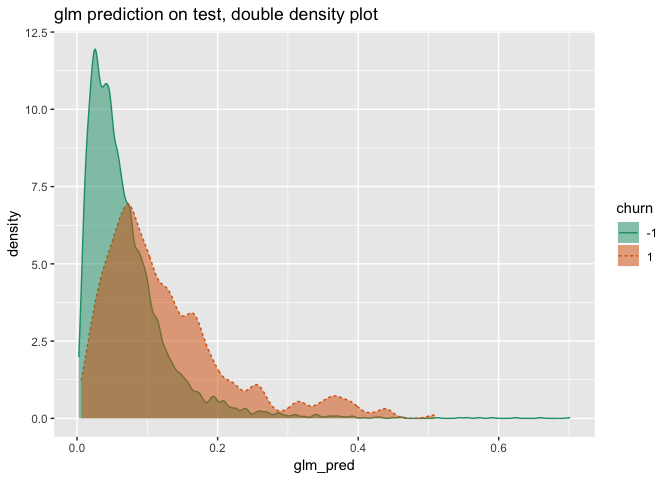

```r
# informalexample 8.16 of section 8.4.2
# (informalexample 8.16 of section 8.4.2)  : Advanced Data Preparation : Advanced data preparation for classification : Building a model

WVPlots::DoubleDensityPlot(dTest_treated, "glm_pred", "churn",
                           "glm prediction on test, double density plot")
```

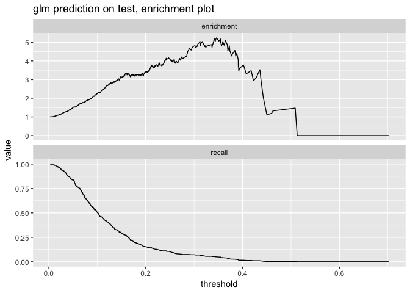

```r
WVPlots::PRTPlot(dTest_treated, "glm_pred", "churn",
                 "glm prediction on test, enrichment plot",
                 truthTarget = 1,
                 plotvars = c("enrichment", "recall"),
                 thresholdrange = c(0, 1.0))
```

00350_informalexample_8.17_of_section_8.5.R

```r
# informalexample 8.17 of section 8.5
# (informalexample 8.17 of section 8.5)  : Advanced Data Preparation : Preparing data for regression modeling

auto_mpg <- readRDS('../auto_mpg/auto_mpg.RDS')

knitr::kable(head(auto_mpg))    # Note: 1
```

| mpg | cylinders | displacement | horsepower | weight | acceleration | model_year | origin | car_name |
| --- | --- | --- | --- | --- | --- | --- | --- | --- |
| 18 | 8 | 307 | 130 | 3504 | 12.0 | 70 | 1 | "chevrolet chevelle malibu" |
| 15 | 8 | 350 | 165 | 3693 | 11.5 | 70 | 1 | "buick skylark 320" |
| 18 | 8 | 318 | 150 | 3436 | 11.0 | 70 | 1 | "plymouth satellite" |
| 16 | 8 | 304 | 150 | 3433 | 12.0 | 70 | 1 | "amc rebel sst" |
| 17 | 8 | 302 | 140 | 3449 | 10.5 | 70 | 1 | "ford torino" |
| 15 | 8 | 429 | 198 | 4341 | 10.0 | 70 | 1 | "ford galaxie 500" |

```r
# Note 1:
#   Take a quick look at the data.
```

00351_informalexample_8.18_of_section_8.5.R

```r
# informalexample 8.18 of section 8.5
# (informalexample 8.18 of section 8.5)  : Advanced Data Preparation : Preparing data for regression modeling

library("wrapr")

vars <- c("cylinders", "displacement",      # Note: 1
          "horsepower", "weight", "acceleration",
          "model_year", "origin")
f <- mk_formula("mpg", vars)
model <- lm(f, data = auto_mpg)

auto_mpg$prediction <- predict(model, newdata = auto_mpg)   # Note: 2

str(auto_mpg[!complete.cases(auto_mpg), , drop = FALSE])
```

```
## 'data.frame':    6 obs. of  10 variables:
##  $ mpg         : num  25 21 40.9 23.6 34.5 23
##  $ cylinders   : num  4 6 4 4 4 4
##  $ displacement: num  98 200 85 140 100 151
##  $ horsepower  : num  NA NA NA NA NA NA
##  $ weight      : num  2046 2875 1835 2905 2320 ...
##  $ acceleration: num  19 17 17.3 14.3 15.8 20.5
##  $ model_year  : num  71 74 80 80 81 82
##  $ origin      : Factor w/ 3 levels "1","2","3": 1 1 2 1 2 1
##  $ car_name    : chr  "\"ford pinto\"" "\"ford maverick\"" "\"renault lecar deluxe\"" "\"ford mustang cobra\"" ...
##  $ prediction  : num  NA NA NA NA NA NA
```

```r
# 'data.frame':    6 obs. of  10 variables:
#  $ mpg         : num  25 21 40.9 23.6 34.5 23
#  $ cylinders   : num  4 6 4 4 4 4
#  $ displacement: num  98 200 85 140 100 151
#  $ horsepower  : num  NA NA NA NA NA NA           # Note: 3
#  $ weight      : num  2046 2875 1835 2905 2320 ...
#  $ acceleration: num  19 17 17.3 14.3 15.8 20.5
#  $ model_year  : num  71 74 80 80 81 82
#  $ origin      : Factor w/ 3 levels "1","2","3": 1 1 2 1 2 1
#  $ car_name    : chr  "\"ford pinto\"" "\"ford maverick\"" "\"renault lecar deluxe\"" "\"ford mustang cobra\"" ...
#  $ prediction  : num  NA NA NA NA NA NA           # Note: 4

# Note 1:
#   Jump into modeling without bothering to treat the data.

# Note 2:
#   Add the model predictions as a new column.

# Note 3:
#   Notice these cars do not have a recorded horsepower.

# Note 4:
#   So these cars do not get a prediction.
```

00352_informalexample_8.19_of_section_8.5.R

```r
# informalexample 8.19 of section 8.5
# (informalexample 8.19 of section 8.5)  : Advanced Data Preparation : Preparing data for regression modeling

library("vtreat")

cfe <- mkCrossFrameNExperiment(auto_mpg, vars, "mpg",   # Note: 1
                               verbose = FALSE)
treatment_plan <- cfe$treatments
auto_mpg_treated <- cfe$crossFrame
score_frame <- treatment_plan$scoreFrame
new_vars <- score_frame$varName

newf <- mk_formula("mpg", new_vars)
new_model <- lm(newf, data = auto_mpg_treated)

auto_mpg$prediction <- predict(new_model, newdata = auto_mpg_treated)
# Warning in predict.lm(new_model, newdata = auto_mpg_treated): prediction
# from a rank-deficient fit may be misleading
str(auto_mpg[!complete.cases(auto_mpg), , drop = FALSE])
```

```
## 'data.frame':    6 obs. of  10 variables:
##  $ mpg         : num  25 21 40.9 23.6 34.5 23
##  $ cylinders   : num  4 6 4 4 4 4
##  $ displacement: num  98 200 85 140 100 151
##  $ horsepower  : num  NA NA NA NA NA NA
##  $ weight      : num  2046 2875 1835 2905 2320 ...
##  $ acceleration: num  19 17 17.3 14.3 15.8 20.5
##  $ model_year  : num  71 74 80 80 81 82
##  $ origin      : Factor w/ 3 levels "1","2","3": 1 1 2 1 2 1
##  $ car_name    : chr  "\"ford pinto\"" "\"ford maverick\"" "\"renault lecar deluxe\"" "\"ford mustang cobra\"" ...
##  $ prediction  : num  24.2 22.3 35.4 25.9 33 ...
```

```r
# 'data.frame':    6 obs. of  10 variables:
#  $ mpg         : num  25 21 40.9 23.6 34.5 23
#  $ cylinders   : num  4 6 4 4 4 4
#  $ displacement: num  98 200 85 140 100 151
#  $ horsepower  : num  NA NA NA NA NA NA
#  $ weight      : num  2046 2875 1835 2905 2320 ...
#  $ acceleration: num  19 17 17.3 14.3 15.8 20.5
#  $ model_year  : num  71 74 80 80 81 82
#  $ origin      : Factor w/ 3 levels "1","2","3": 1 1 2 1 2 1
#  $ car_name    : chr  "\"ford pinto\"" "\"ford maverick\"" "\"renault lecar deluxe\"" "\"ford mustang cobra\"" ...
#  $ prediction  : num  24.6 22.4 34.2 26.1 33.3 ...    # Note: 2

# Note 1:
#   Try it again with vtreat data preparation.

# Note 2:
#   Now we can make predictions, even for items that have missing data.
```

00353_informalexample_8.20_of_section_8.6.2.R

```r
# informalexample 8.20 of section 8.6.2
# (informalexample 8.20 of section 8.6.2)  : Advanced Data Preparation : Mastering the vtreat package : Missing values

library("wrapr")    # Note: 1

d <- build_frame(
   "x1"    , "x2"         , "x3", "y" |
   1       , "a"          , 6   , 10  |
   NA_real_, "b"          , 7   , 20  |
   3       , NA_character_, 8   , 30  )

knitr::kable(d)
```

| x1 | x2 | x3 | y |
| --- | --- | --- | --- |
| 1 | a | 6 | 10 |
| NA | b | 7 | 20 |
| 3 | NA | 8 | 30 |

```r
# Note 1:
#   Bring in the wrapr package for build_frame and the wrapr "dot pipe".
```

00354_informalexample_8.21_of_section_8.6.2.R

```r
# informalexample 8.21 of section 8.6.2
# (informalexample 8.21 of section 8.6.2)  : Advanced Data Preparation : Mastering the vtreat package : Missing values

plan1 <- vtreat::design_missingness_treatment(d)
vtreat::prepare(plan1, d) %.>%      # Note: 1
   knitr::kable(.)
```

| x1 | x1_isBAD | x2 | x3 | y |
| --- | --- | --- | --- | --- |
| 1 | 0 | a | 6 | 10 |
| 2 | 1 | b | 7 | 20 |
| 3 | 0 | *invalid* | 8 | 30 |

```r
# Note 1:
#   Here we are using wrapr's "dot pipe" instead of magrittr's forward pipe. The dot pipe requires the "explicit dot argument" notation discussed in chapter 5.
```

00355_informalexample_8.22_of_section_8.6.3.R

```r
# informalexample 8.22 of section 8.6.3
# (informalexample 8.22 of section 8.6.3)  : Advanced Data Preparation : Mastering the vtreat package : Indicator variables

d <- build_frame(
   "x1"    , "x2"         , "x3", "y" |
   1       , "a"          , 6   , 10  |
   NA_real_, "b"          , 7   , 20  |
   3       , NA_character_, 8   , 30  )

print(d)
```

```
##   x1   x2 x3  y
## 1  1    a  6 10
## 2 NA    b  7 20
## 3  3 <NA>  8 30
```

```r
#   x1   x2 x3  y
# 1  1    a  6 10
# 2 NA    b  7 20           # Note: 1
# 3  3 <NA>  8 30
plan2 <- vtreat::designTreatmentsZ(d,
                                   varlist = c("x1", "x2", "x3"),
                                   verbose = FALSE)
vtreat::prepare(plan2, d)
```

```
##   x1 x1_isBAD x3 x2_lev_NA x2_lev_x_a x2_lev_x_b
## 1  1        0  6         0          1          0
## 2  2        1  7         0          0          1
## 3  3        0  8         1          0          0
```

```r
#   x1 x1_isBAD x3 x2_lev_NA x2_lev_x_a x2_lev_x_b
# 1  1        0  6         0          1          0
# 2  2        1  7         0          0          1  # Note: 2
# 3  3        0  8         1          0          0

# Note 1:
#   The second value of x2 is "b"

# Note 2:
#   In the second row of the treated data, x2_lev_x_b = 1
```

00356_informalexample_8.23_of_section_8.6.4.R

```r
# informalexample 8.23 of section 8.6.4
# (informalexample 8.23 of section 8.6.4)  : Advanced Data Preparation : Mastering the vtreat package : Impact coding

d <- build_frame(
   "x1"    , "x2"         , "x3", "y" |
   1       , "a"          , 6   , 10  |
   NA_real_, "b"          , 7   , 20  |
   3       , NA_character_, 8   , 30  )

print(d)
```

```
##   x1   x2 x3  y
## 1  1    a  6 10
## 2 NA    b  7 20
## 3  3 <NA>  8 30
```

```r
#   x1   x2 x3  y
# 1  1    a  6 10
# 2 NA    b  7 20
# 3  3 <NA>  8 30
plan3 <- vtreat::designTreatmentsN(d,
                                   varlist = c("x1", "x2", "x3"),
                                   outcomename = "y",
                                   codeRestriction = "catN",
                                   verbose = FALSE)
vtreat::prepare(plan3, d)
```

```
##   x2_catN  y
## 1     -10 10
## 2       0 20
## 3      10 30
```

```r
#   x2_catN  y
# 1     -10 10
# 2       0 20
# 3      10 30
```

00357_informalexample_8.24_of_section_8.6.4.R

```r
# informalexample 8.24 of section 8.6.4
# (informalexample 8.24 of section 8.6.4)  : Advanced Data Preparation : Mastering the vtreat package : Impact coding

plan4 <- vtreat::designTreatmentsC(d,
                                   varlist = c("x1", "x2", "x3"),
                                   outcomename = "y",
                                   outcometarget = 20,
                                   codeRestriction = "catB",
                                   verbose = FALSE)
vtreat::prepare(plan4, d)
```

```
##     x2_catB  y
## 1 -8.517343 10
## 2  9.903538 20
## 3 -8.517343 30
```

```r
#     x2_catB  y
# 1 -8.517343 10
# 2  9.903538 20
# 3 -8.517343 30
```

00358_informalexample_8.25_of_section_8.6.5.R

```r
# informalexample 8.25 of section 8.6.5
# (informalexample 8.25 of section 8.6.5)  : Advanced Data Preparation : Mastering the vtreat package : The treatment plan

class(plan4)
```

```
## [1] "treatmentplan"
```

```r
# [1] "treatmentplan"

names(plan4)
```

```
## [1] "treatments"    "scoreFrame"    "outcomename"   "vtreatVersion"
## [5] "outcomeType"   "outcomeTarget" "meanY"         "splitmethod"
```

```r
# [1] "treatments"    "scoreFrame"    "outcomename"   "vtreatVersion" "outcomeType"
# [6] "outcomeTarget" "meanY"         "splitmethod"
```

00359_informalexample_8.26_of_section_8.6.5.R

```r
# informalexample 8.26 of section 8.6.5
# (informalexample 8.26 of section 8.6.5)  : Advanced Data Preparation : Mastering the vtreat package : The treatment plan

plan4$scoreFrame
```

```
##   varName varMoves rsq       sig needsSplit extraModelDegrees origName
## 1 x2_catB     TRUE   1 0.0506719       TRUE                 2       x2
##   code
## 1 catB
```

```r
#   varName varMoves rsq       sig needsSplit extraModelDegrees origName code
# 1 x2_catB     TRUE   1 0.0506719       TRUE                 2       x2 catB
```

00360_example_8.8_of_section_8.6.6.R

```r
# example 8.8 of section 8.6.6
# (example 8.8 of section 8.6.6)  : Advanced Data Preparation : Mastering the vtreat package : The cross-frame
# Title: An information-free data set

set.seed(2019)  # Note: 1

d <- data.frame(    # Note: 2
  x_bad = sample(letters, 100, replace = TRUE),
  y = rnorm(100),
  stringsAsFactors = FALSE
)
d$x_good <- ifelse(d$y > rnorm(100), "non-neg", "neg")  # Note: 3


head(d)     # Note: 4
```

```
##   x_bad           y  x_good
## 1     u -0.05294738 non-neg
## 2     s -0.23639840     neg
## 3     h -0.33796351 non-neg
## 4     q -0.75548467 non-neg
## 5     b -0.86159347     neg
## 6     b -0.52766549 non-neg
```

```r
#   x_bad           y  x_good
# 1     u -0.05294738 non-neg
# 2     s -0.23639840     neg
# 3     h -0.33796351 non-neg
# 4     q -0.75548467 non-neg
# 5     b -0.86159347     neg
# 6     b -0.52766549 non-neg

# Note 1:
#   Set pseudo-random number generator seed to make example reproducible.

# Note 2:
#   Build example data where there is no relation between x_bad and y.

# Note 3:
#   x_good is a noisy prediction of the sign of y, so it does have some information about y.

# Note 4:
#   Take a look at our synthetic example data. The idea is: y is related to x_good in a noisy fashion, but unrelated to x_bad.
#   In this case we know what variables should be chosen, so we can tell if our acceptance procedure is working correctly.
```

00361_example_8.9_of_section_8.6.6.R

```r
# example 8.9 of section 8.6.6
# (example 8.9 of section 8.6.6)  : Advanced Data Preparation : Mastering the vtreat package : The cross-frame
# Title: The dangers of re-using data

plan5 <- vtreat::designTreatmentsN(d,   # Note: 1
                                   varlist = c("x_bad", "x_good"),
                                   outcomename = "y",
                                   codeRestriction = "catN",
                                   minFraction = 2,
                                   verbose = FALSE)

class(plan5)
```

```
## [1] "treatmentplan"
```

```r
# [1] "treatmentplan"

print(plan5)    # Note: 2
```

```
##   origName     varName code          rsq          sig extraModelDegrees
## 1    x_bad  x_bad_catN catN 4.906903e-05 9.448548e-01                24
## 2   x_good x_good_catN catN 2.602702e-01 5.895285e-08                 1
```

```r
#   origName     varName code          rsq          sig extraModelDegrees
# 1    x_bad  x_bad_catN catN 4.906903e-05 9.448548e-01                24
# 2   x_good x_good_catN catN 2.602702e-01 5.895285e-08                 1

training_data1 <- vtreat::prepare(plan5, d)     # Note: 3

res1 <- vtreat::patch_columns_into_frame(d, training_data1)     # Note: 4
head(res1)
```

```
##   x_bad  x_good x_bad_catN x_good_catN           y
## 1     u non-neg  0.4070979   0.4305195 -0.05294738
## 2     s     neg -0.1133011  -0.5706886 -0.23639840
## 3     h non-neg -0.3202346   0.4305195 -0.33796351
## 4     q non-neg -0.5447443   0.4305195 -0.75548467
## 5     b     neg -0.3890076  -0.5706886 -0.86159347
## 6     b non-neg -0.3890076   0.4305195 -0.52766549
```

```r
#   x_bad  x_good x_bad_catN x_good_catN           y
# 1     u non-neg  0.4070979   0.4305195 -0.05294738
# 2     s     neg -0.1133011  -0.5706886 -0.23639840
# 3     h non-neg -0.3202346   0.4305195 -0.33796351
# 4     q non-neg -0.5447443   0.4305195 -0.75548467
# 5     b     neg -0.3890076  -0.5706886 -0.86159347
# 6     b non-neg -0.3890076   0.4305195 -0.52766549

sigr::wrapFTest(res1, "x_good_catN", "y")   # Note: 5
```

```
## [1] "F Test summary: (R2=0.2717, F(1,98)=36.56, p<1e-05)."
```

```r
# [1] "F Test summary: (R2=0.2717, F(1,98)=36.56, p<1e-05)."

sigr::wrapFTest(res1, "x_bad_catN", "y")    # Note: 6
```

```
## [1] "F Test summary: (R2=0.2342, F(1,98)=29.97, p<1e-05)."
```

```r
# [1] "F Test summary: (R2=0.2342, F(1,98)=29.97, p<1e-05)."

# Note 1:
#   Design a variable treatment plan using x_bad and x_good to try and predict y.

# Note 2:
#   Notice the derived variable x_good_catN comes out as having a significant signal, and x_bad_catN does not.
#   This is due to proper cross-validation in estimating the variable qualities.

# Note 3:
#   Call prepare() on the same data used to design the treatment plan- this is not always safe, as we shall see.

# Note 4:
#   Combine the data frames d an training_data1, using training_data1 when there are columns with duplicate names.

# Note 5:
#   Use a statistical F-test to check the predictive power of x_good_catN.

# Note 6:
#   x_bad_catN's F-test is inflated and falsely looks significant.
```

00362_example_8.10_of_section_8.6.6.R

```r
# example 8.10 of section 8.6.6
# (example 8.10 of section 8.6.6)  : Advanced Data Preparation : Mastering the vtreat package : The cross-frame
# Title: Using mkCrossFrameNExperiment()

cfe <- vtreat::mkCrossFrameNExperiment(d,
                                       varlist = c("x_bad", "x_good"),
                                       outcomename = "y",
                                       codeRestriction = "catN",
                                       minFraction = 2,
                                       verbose = FALSE)
plan6 <- cfe$treatments

training_data2 <- cfe$crossFrame
res2 <- vtreat::patch_columns_into_frame(d, training_data2)

head(res2)
```

```
##   x_bad  x_good x_bad_catN x_good_catN           y
## 1     u non-neg  0.2834739   0.4193180 -0.05294738
## 2     s     neg -0.1085887  -0.6212118 -0.23639840
## 3     h non-neg  0.0000000   0.5095586 -0.33796351
## 4     q non-neg -0.5142570   0.5095586 -0.75548467
## 5     b     neg -0.3540889  -0.6212118 -0.86159347
## 6     b non-neg -0.3540889   0.4193180 -0.52766549
```

```r
#   x_bad  x_good x_bad_catN x_good_catN           y
# 1     u non-neg  0.2834739   0.4193180 -0.05294738
# 2     s     neg -0.1085887  -0.6212118 -0.23639840
# 3     h non-neg  0.0000000   0.5095586 -0.33796351
# 4     q non-neg -0.5142570   0.5095586 -0.75548467
# 5     b     neg -0.3540889  -0.6212118 -0.86159347
# 6     b non-neg -0.3540889   0.4193180 -0.52766549

sigr::wrapFTest(res2, "x_bad_catN", "y")
```

```
## [1] "F Test summary: (R2=-0.1389, F(1,98)=-11.95, p=n.s.)."
```

```r
# [1] "F Test summary: (R2=-0.1389, F(1,98)=-11.95, p=n.s.)."

sigr::wrapFTest(res2, "x_good_catN", "y")
```

```
## [1] "F Test summary: (R2=0.2532, F(1,98)=33.22, p<1e-05)."
```

```r
# [1] "F Test summary: (R2=0.2532, F(1,98)=33.22, p<1e-05)."

plan6$scoreFrame    # Note: 1
```

```
##       varName varMoves        rsq          sig needsSplit
## 1  x_bad_catN     TRUE 0.01436145 2.349865e-01       TRUE
## 2 x_good_catN     TRUE 0.26478467 4.332649e-08       TRUE
##   extraModelDegrees origName code
## 1                24    x_bad catN
## 2                 1   x_good catN
```

```r
#       varName varMoves        rsq          sig needsSplit
# 1  x_bad_catN     TRUE 0.01436145 2.349865e-01       TRUE
# 2 x_good_catN     TRUE 0.26478467 4.332649e-08       TRUE
#   extraModelDegrees origName code
# 1                24    x_bad catN
# 2                 1   x_good catN

# Note 1:
#   The F-tests on the data and the scoreFrame statistics now largely agree.
```